# Tidy model with R 笔记

```r
library(tidyverse)
library(tidymodels)
tidymodels_prefer(quiet = TRUE)
```

# 实战：一组买房子的数据

使用的数据是一组爱荷华州Ames的房屋销售数据。构建模型的目的是预测房屋售价。

```r
data(ames, package = "modeldata")

dim(ames)
```

```
## [1] 2930   74
```

```r
glimpse(ames)
```

```
## Rows: 2,930
## Columns: 74
## $ MS_SubClass        <fct> One_Story_1946_and_Newer_All_Styles, One_Story_1946…
## $ MS_Zoning          <fct> Residential_Low_Density, Residential_High_Density, …
## $ Lot_Frontage       <dbl> 141, 80, 81, 93, 74, 78, 41, 43, 39, 60, 75, 0, 63,…
## $ Lot_Area           <int> 31770, 11622, 14267, 11160, 13830, 9978, 4920, 5005…
## $ Street             <fct> Pave, Pave, Pave, Pave, Pave, Pave, Pave, Pave, Pav…
## $ Alley              <fct> No_Alley_Access, No_Alley_Access, No_Alley_Access, …
## $ Lot_Shape          <fct> Slightly_Irregular, Regular, Slightly_Irregular, Re…
## $ Land_Contour       <fct> Lvl, Lvl, Lvl, Lvl, Lvl, Lvl, Lvl, HLS, Lvl, Lvl, L…
## $ Utilities          <fct> AllPub, AllPub, AllPub, AllPub, AllPub, AllPub, All…
## $ Lot_Config         <fct> Corner, Inside, Corner, Corner, Inside, Inside, Ins…
## $ Land_Slope         <fct> Gtl, Gtl, Gtl, Gtl, Gtl, Gtl, Gtl, Gtl, Gtl, Gtl, G…
## $ Neighborhood       <fct> North_Ames, North_Ames, North_Ames, North_Ames, Gil…
## $ Condition_1        <fct> Norm, Feedr, Norm, Norm, Norm, Norm, Norm, Norm, No…
```

[output cut: 61 more lines]

## 熟悉数据，开始探索性分析

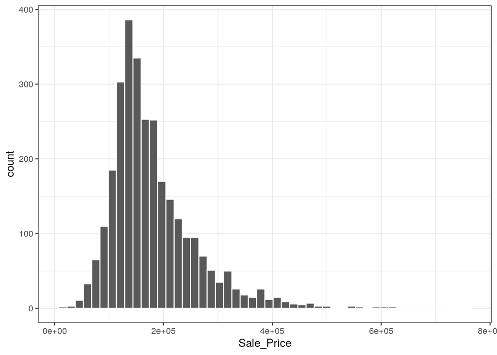

```r
ggplot(ames, aes(x = Sale_Price)) +
  geom_histogram(bins = 50, col= "white") +
  theme_bw()
```

使用log变换的考量：

- 变换之后，预测的售价不会为负。
- 变换之后，对离群值（高售价房屋）的预测不会特别离谱。
- 统计学上看，log变换可以稳定方差

用log变换的缺点：

- 均方根误差（root mean square error, RMSE）用来评价回归模型，计算RMSE要用残差。如果残差是log transformed那RMSE会令人难以理解。

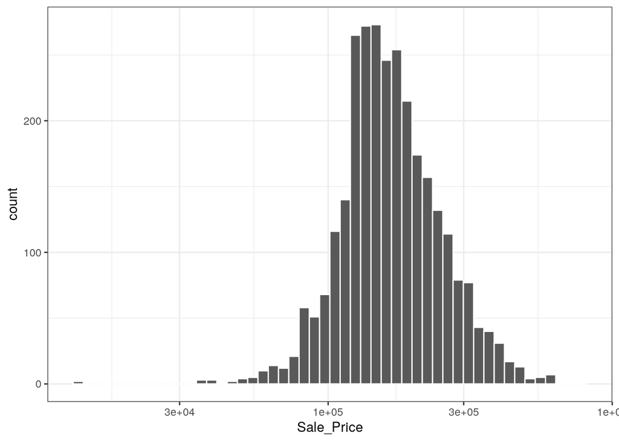

```r
ggplot(ames, aes(x = Sale_Price)) +
  geom_histogram(bins = 50, color = "white") +
  scale_x_log10() +
  theme_bw()
```

不管怎样，还是用log transfered数据做后续分析：

```r
ames <- ames %>% mutate(Sale_Price = log10(Sale_Price))
```

## 数据预算和数据分层

在建模过程中，比较好的实践是对数据的使用规划“预算”。

- 对某个模型只使用有限的数据进行建模。
  - 数据的选择根据经验或数据特征，有方法。
  - 好处是避免放大bias，或者方法学错误的积累。

### 分数据

最简单的是分两份：训练集和测试集。但是怎么分呢？

```r
set.seed(501)

# rsample：取样的包
ames_split <- rsample::initial_split(ames, prop = 0.8)
ames_split
```

```
## <Training/Testing/Total>
## <2344/586/2930>
```

```r
ames_train <- rsample::training(ames_split)  # 获取训练集
ames_test <- rsample::testing(ames_split)  # 获取测试集

dim(ames_train)
```

```
## [1] 2344   74
```

更多的情况下，随机取样并不合适，需要分层抽样（stratafied sampling）。

- 用分层抽样几乎没缺点。

```r
set.seed(502)
ames_split <- initial_split(ames, prop = 0.8, strata = Sale_Price)
ames_train <- training(ames_split)
ames_test <- testing(ames_split)

dim(ames_train)
```

```
## [1] 2342   74
```

```r
summary(ames_train$Sale_Price)
```

```
##    Min. 1st Qu.  Median    Mean 3rd Qu.    Max.
##   4.107   5.112   5.204   5.221   5.329   5.878
```

```r
summary(ames_test$Sale_Price)
```

```
##    Min. 1st Qu.  Median    Mean 3rd Qu.    Max.
##   4.543   5.112   5.205   5.219   5.329   5.872
```

当变量中有时序变量时，最好使用最近的数据作为测试集。这时使用`rsample::initial_time_split()`按数据本身的顺序进行取样，所以使用前要先对数据按时序变量做排序。

### 验证集

当需要使用验证集（validation set）时，可以使用：

```r
set.seed(52)
# 6/2/2分成
ames_val_split <- rsample::initial_validation_split(
  ames,
  prop = c(0.6, 0.2),  # for train and val, the rest goes to test
  strata = Sale_Price
)
ames_val_split
```

```
## <Training/Validation/Testing/Total>
## <1756/587/587/2930>
```

```r
# ames_train <- training(ames_val_split)
# ames_test <- testing(ames_val_split)
# ames_val <- rsample::validation(ames_val_split)
```

### 小tips

- 数据分层应该发生在数据点相互独立的那一层。
  - 纵向数据中，一个数据点可能进行多次重复取样。比如一个患者的术后随访，分层应该对患者分，而不是随访检测，保证同一个患者的所有检测都被分到同一个分层中。
- 测试集要保证和模型构建过程隔离，避免信息泄漏（information leakage）。
  - 在构建阶段使用测试集数据可以是间接的，且需要避免。例如只使用在训练集中，和测试集特征最接近的数据点进行模型构建。
- 不要滥用训练集的子集，要用就全用。
- 确保测试集总能代表新增数据。
- 确保数据在不同的任务中不被复用/滥用，进而导致过拟合和偏倚。
- 在模型确定之后，可以用全部数据进行参数优化。

## 用`parsnip`包拟合模型

数据确定了就可以拟合模型了。`Tidymodels`的接口分三步：

- 选择模型结构：比如线性回归，随机森林，KNN，etc
- 选择一个“引擎”：在线性回归模型里，可以选来自`rstanarm`包或者`glmnet`包提供的函数，这些都是“引擎”，`parsnip`包底层整理这些函数到统一的接口。
- （可选）声明模型的模式：
  - 有的模型适用于不同类型的变量，连续型变量就是回归，离散型变量就是分类。
  - 有的模型只适用于一种类型的变量，不需要声明模式。

```r
# 使用不同引擎的建模：
linear_reg() %>% set_engine("lm")
```

```
## Linear Regression Model Specification (regression)
##
## Computational engine: lm
```

```r
linear_reg() %>% set_engine("glmnet")
```

```
## Linear Regression Model Specification (regression)
##
## Computational engine: glmnet
```

```r
linear_reg() %>% set_engine("stan")
```

```
## Linear Regression Model Specification (regression)
##
## Computational engine: stan
```

`parsnip`的接口如何处理代码：

```r
linear_reg() %>% set_engine("lm") %>% parsnip::translate()
```

```
## Linear Regression Model Specification (regression)
##
## Computational engine: lm
##
## Model fit template:
## stats::lm(formula = missing_arg(), data = missing_arg(), weights = missing_arg())
```

注意到`missing_arg()`作为占位符。

### 实例

```r
lm_model <-
  linear_reg() %>%
  set_engine("lm")
lm_form_fit <-
  lm_model %>%
  fit(Sale_Price ~ Longitude + Latitude, data = ames_train)
  # fit()是泛函，parsnip给加了方法

lm_xy_fit <-
  lm_model %>%
  fit_xy(
    x = ames_train %>% select(Longitude, Latitude),
    y = ames_train %>% pull(Sale_Price)
  )

# 据说fix_xy()不会创建dummy predictor变量，再之后有说明
```

```r
lm_form_fit
```

```
## parsnip model object
##
##
## Call:
## stats::lm(formula = Sale_Price ~ Longitude + Latitude, data = data)
##
## Coefficients:
## (Intercept)    Longitude     Latitude
##    -302.974       -2.075        2.710
```

```r
lm_xy_fit
```

```
## parsnip model object
##
##
## Call:
## stats::lm(formula = ..y ~ ., data = data)
##
## Coefficients:
## (Intercept)    Longitude     Latitude
##    -302.974       -2.075        2.710
```

`parsnip`的接口在处理传递给模型函数的参数时，会把参数分成两类：

- 常用的，一般是必须给的，同一个功能其它函数也泛用的。比如数据，比如随机森林的`tree`。
- 非泛用的，一般是这个函数独有的。比如`ranger::ranger(num.threads = 1)`。
  - 这类参数`parsnip`接口会给出默认，可以通过`set_engine()`修改。

`parsnip`模型的结果保存在`parsnip::model_fit`对象里，通过`extract_fit_engine()`可以提取拟合好的模型。

```r
extract_fit_engine(lm_form_fit)
```

```
##
## Call:
## stats::lm(formula = Sale_Price ~ Longitude + Latitude, data = data)
##
## Coefficients:
## (Intercept)    Longitude     Latitude
##    -302.974       -2.075        2.710
```

拟合结果一般可以直接拿来用：

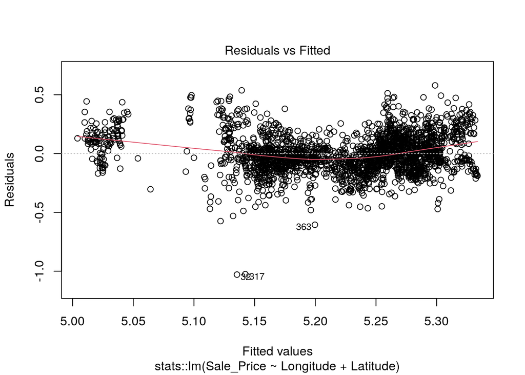

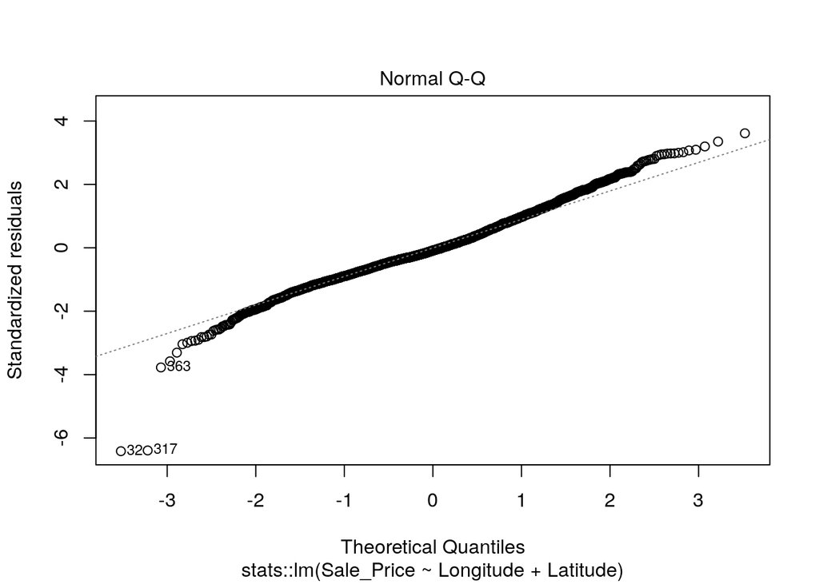

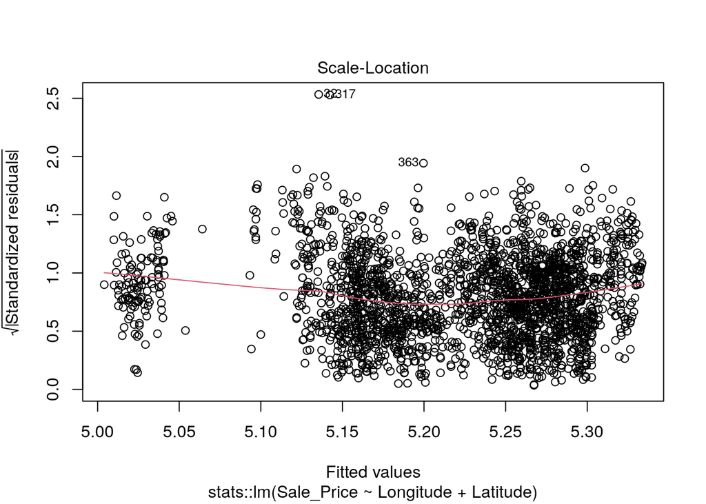

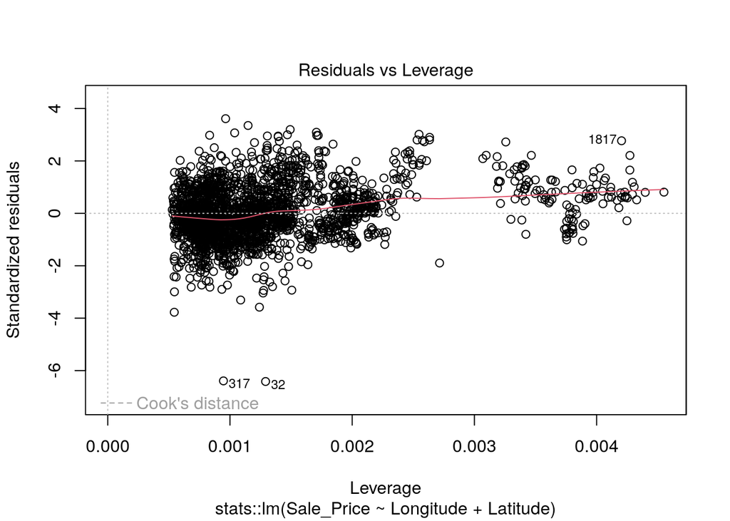

```r
lm_form_fit %>% extract_fit_engine() %>% plot()
```

把模型结果保存并提取信息的功能，还能更进一步：

```r
model_res <-
  lm_form_fit %>%
  extract_fit_engine() %>%
  summary()
param_est <- coef(model_res)  # lm模型的相关系数表

class(param_est)
```

```
## [1] "matrix" "array"
```

```r
param_est
```

```
##                Estimate Std. Error   t value     Pr(>|t|)
## (Intercept) -302.973554 14.3983093 -21.04230 3.640103e-90
## Longitude     -2.074862  0.1286322 -16.13019 1.395257e-55
## Latitude       2.709654  0.1803877  15.02128 9.289500e-49
```

提取信息还能再进一步

```r
broom::tidy(lm_form_fit)
```

| term | estimate | std.error | statistic | p.value |
| --- | --- | --- | --- | --- |
| (Intercept) | -302.973554 | 14.3983093 | -21.04230 | 3.640103e-90 |
| Longitude | -2.074862 | 0.1286322 | -16.13019 | 1.395257e-55 |
| Latitude | 2.709654 | 0.1803877 | 15.02128 | 9.289500e-49 |

### `parsnip`对`predict()`的接口

简单来说就是返回`tibble`，更直给，且输出匹配输入（数量/顺序/…）。

```r
ames_test_small <- ames_test %>% slice(1:5)
predict(lm_form_fit, new_data = ames_test_small)
```

| .pred |
| --- |
| 5.223658 |
| 5.213810 |
| 5.284813 |
| 5.273753 |
| 5.280470 |

好处非常明显：

```r
ames_test_small %>%
  select(Sale_Price) %>%
  bind_cols(
    predict(lm_form_fit, ames_test_small)
  ) %>%
  bind_cols(
    predict(lm_form_fit, ames_test_small, type = "pred_int")
    # 置信区间，具体会返回什么参考`help(predict.model_fit)`
  )
```

| Sale_Price | .pred | .pred_lower | .pred_upper |
| --- | --- | --- | --- |
| 5.021189 | 5.223658 | 4.908902 | 5.538413 |
| 5.387390 | 5.213810 | 4.899055 | 5.528565 |
| 5.278525 | 5.284813 | 4.970037 | 5.599589 |
| 5.282169 | 5.273753 | 4.958973 | 5.588533 |
| 5.276462 | 5.280470 | 4.965711 | 5.595229 |

整个操作下来，会发现`parsnip`接口的一致性：

```r
# 换成决策树模型
tree_model <-
  decision_tree(min_n = 2) %>%
  set_engine("rpart") %>%
  set_mode("regression")
tree_fit <-
  tree_model %>%
  fit(Sale_Price ~ Longitude + Latitude, data = ames_train)  # 完全一致
ames_test_small %>%
  select(Sale_Price) %>%
  bind_cols(
    predict(tree_fit, ames_test_small)
  )
```

| Sale_Price | .pred |
| --- | --- |
| 5.021189 | 5.151773 |
| 5.387390 | 5.151773 |
| 5.278525 | 5.320438 |
| 5.282169 | 5.320438 |
| 5.276462 | 5.320438 |

### `parsnip`接口的扩展

- 已经支持的包和模型可通过[官网](https://www.tidymodels.org/find/)查询。
- 也可通过`parsnip_addin()`调出的界面来查询，这些支持不全在`parsnip`包里。
  - 能调出一个生成模板代码的shiny app，帅~

```r
parsnip::parsnip_addin()
```